# **第二章：探索性数据分析**

本章内容简介：

- 2.1 目的
- 2.2 数据探索
- 2.3 结论

## 2.1 目的

如今，多数的生态学实验都需要进行假设检验和建模等数据处理。 然而，在应对多维数据情景时，具有简单数据统计分析和可视化的探索性数据分析（exploratory data analysis，EDA）方法仍然需要对原数据进行简单的预处理过程：

- 获取数据的整体概况
- 对某些变量进行转换或者重编码
- 对数据进行排序

本章使用 Doubs 河流数据集上进行数据探索分析，通过实际的操作演练以期达到一下 3 个目的：

- 学习和掌握 R 语言的一些基本函数功能
- 学习和掌握应用探索性数据分析方式处理多维生态数据
- 对 Doubs 河流数据集中的水文数据进行探索性分析

## 2.2 数据探索

### 2.2.1 数据提取

Doubs 河流数据集的相关信息保存在 .RData 文件中

```r
# 解决警告信息的显示问题
# Warning: Input string not available in this locale
Sys.setlocale('LC_ALL','C')
```

```
## [1] "C"
```

```r
# 导入所需要的 R 分析包
library(vegan)
library(RgoogleMaps)
library(googleVis)
library(labdsv)
# 注意所需要的分析脚本和原数据的路径 与 已设置的工作路劲
source("Functions/panelutils.R") # 调用分析脚本文件

load("Data/Doubs.RData") # 导入处于工作路径中的 Doubs 河流数据集

# Doubs 河流数据集有一下几个 R 数据对象：
# spe: 物种（群落）数据框（鱼的丰度信息）
# env: 环境信息数据框
# spa: 空间地理信息数据框 – 笛卡尔坐标系
# fishtraits: 鱼物种的功能性特征信息
# latlong: 空间地理信息数据框 – 经纬度
```

> 1. 分析脚本和数据文件所处的路径位置应在已设置的工作路径中，可以使用 getwd() 查看已设置的工作路径 和 setwd() 重新设置工作路径;
> 2. 建议使用 Rstudio 作为读者与 R 交流的媒介，同时亦可使用 Rstudio 作为脚本管理器进行编辑 R 类型的脚本文档，同时 Rstudio 可以很方便的重新设置工作路径;
> 3. 使用 class() 查询 R 对象的数据类型

### 2.2.2 物种数据: 初次

以群落数据 - spe - 开始探索性数据分析：使用 R 基本函数进行初步探索分析并绘制条形图（barplot）

```r
# 上文中已导入 Doubs 河流数据集
spe # 查看 子数据集 spe 的概况
```

```
##    Cogo Satr Phph Babl Thth Teso Chna Pato Lele Sqce Baba Albi Gogo Eslu
## 1     0    3    0    0    0    0    0    0    0    0    0    0    0    0
## 2     0    5    4    3    0    0    0    0    0    0    0    0    0    0
## 3     0    5    5    5    0    0    0    0    0    0    0    0    0    1
## 4     0    4    5    5    0    0    0    0    0    1    0    0    1    2
## 5     0    2    3    2    0    0    0    0    5    2    0    0    2    4
## 6     0    3    4    5    0    0    0    0    1    2    0    0    1    1
## 7     0    5    4    5    0    0    0    0    1    1    0    0    0    0
## 8     0    0    0    0    0    0    0    0    0    0    0    0    0    0
## 9     0    0    1    3    0    0    0    0    0    5    0    0    0    0
## 10    0    1    4    4    0    0    0    0    2    2    0    0    1    0
## 11    1    3    4    1    1    0    0    0    0    1    0    0    0    0
## 12    2    5    4    4    2    0    0    0    0    1    0    0    0    0
## 13    2    5    5    2    3    2    0    0    0    0    0    0    0    0
## 14    3    5    5    4    4    3    0    0    0    1    1    0    1    1
```

[output cut: 47 more lines]

```r
spe[1:5,  1:10] # 显示前 5 行、前 10列
```

```
##   Cogo Satr Phph Babl Thth Teso Chna Pato Lele Sqce
## 1    0    3    0    0    0    0    0    0    0    0
## 2    0    5    4    3    0    0    0    0    0    0
## 3    0    5    5    5    0    0    0    0    0    0
## 4    0    4    5    5    0    0    0    0    0    1
## 5    0    2    3    2    0    0    0    0    5    2
```

```r
head(spe) # 前 6 行
```

```
##   Cogo Satr Phph Babl Thth Teso Chna Pato Lele Sqce Baba Albi Gogo Eslu
## 1    0    3    0    0    0    0    0    0    0    0    0    0    0    0
## 2    0    5    4    3    0    0    0    0    0    0    0    0    0    0
## 3    0    5    5    5    0    0    0    0    0    0    0    0    0    1
## 4    0    4    5    5    0    0    0    0    0    1    0    0    1    2
## 5    0    2    3    2    0    0    0    0    5    2    0    0    2    4
## 6    0    3    4    5    0    0    0    0    1    2    0    0    1    1
##   Pefl Rham Legi Scer Cyca Titi Abbr Icme Gyce Ruru Blbj Alal Anan
## 1    0    0    0    0    0    0    0    0    0    0    0    0    0
## 2    0    0    0    0    0    0    0    0    0    0    0    0    0
## 3    0    0    0    0    0    0    0    0    0    0    0    0    0
## 4    2    0    0    0    0    1    0    0    0    0    0    0    0
## 5    4    0    0    2    0    3    0    0    0    5    0    0    0
## 6    1    0    0    0    0    2    0    0    0    1    0    0    0
```

```r
tail(spe) # 尾 6 行
```

```
##    Cogo Satr Phph Babl Thth Teso Chna Pato Lele Sqce Baba Albi Gogo Eslu
## 25    0    0    0    0    0    0    0    0    1    1    0    0    2    1
## 26    0    0    0    1    0    0    1    0    1    2    2    1    3    2
## 27    0    0    0    1    0    0    1    1    2    3    4    1    4    4
## 28    0    0    0    1    0    0    1    1    2    4    3    1    4    3
## 29    0    1    1    1    1    1    2    2    3    4    5    3    5    5
## 30    0    0    0    0    0    0    1    2    3    3    3    5    5    4
##    Pefl Rham Legi Scer Cyca Titi Abbr Icme Gyce Ruru Blbj Alal Anan
## 25    0    0    0    1    0    0    0    0    1    1    0    3    0
## 26    1    2    2    1    1    3    2    1    4    4    2    5    2
## 27    1    3    3    1    2    5    3    2    5    5    4    5    3
## 28    2    4    4    2    4    4    3    3    5    5    5    5    4
## 29    4    5    5    2    3    3    4    4    5    5    4    5    4
## 30    5    5    3    5    5    5    5    5    5    5    5    5    5
```

```r
nrow(spe) # 行数
```

```
## [1] 30
```

```r
ncol(spe) # 列数
```

```
## [1] 27
```

```r
dim(spe) # 数据框的维度（行数、列数）
```

```
## [1] 30 27
```

```r
colnames(spe) # 列标签
```

```
##  [1] "Cogo" "Satr" "Phph" "Babl" "Thth" "Teso" "Chna" "Pato" "Lele" "Sqce"
## [11] "Baba" "Albi" "Gogo" "Eslu" "Pefl" "Rham" "Legi" "Scer" "Cyca" "Titi"
## [21] "Abbr" "Icme" "Gyce" "Ruru" "Blbj" "Alal" "Anan"
```

```r
rownames(spe) # 行标签
```

```
##  [1] "1"  "2"  "3"  "4"  "5"  "6"  "7"  "8"  "9"  "10" "11" "12" "13" "14"
## [15] "15" "16" "17" "18" "19" "20" "21" "22" "23" "24" "25" "26" "27" "28"
## [29] "29" "30"
```

```r
summary(spe) # 描述每列的统计信息
```

```
##       Cogo           Satr           Phph            Babl
##  Min.   :0.00   Min.   :0.00   Min.   :0.000   Min.   :0.000
##  1st Qu.:0.00   1st Qu.:0.00   1st Qu.:0.000   1st Qu.:1.000
##  Median :0.00   Median :1.00   Median :3.000   Median :2.000
##  Mean   :0.50   Mean   :1.90   Mean   :2.267   Mean   :2.433
##  3rd Qu.:0.75   3rd Qu.:3.75   3rd Qu.:4.000   3rd Qu.:4.000
##  Max.   :3.00   Max.   :5.00   Max.   :5.000   Max.   :5.000
##       Thth           Teso             Chna          Pato
##  Min.   :0.00   Min.   :0.0000   Min.   :0.0   Min.   :0.0000
##  1st Qu.:0.00   1st Qu.:0.0000   1st Qu.:0.0   1st Qu.:0.0000
##  Median :0.00   Median :0.0000   Median :0.0   Median :0.0000
##  Mean   :0.50   Mean   :0.6333   Mean   :0.6   Mean   :0.8667
##  3rd Qu.:0.75   3rd Qu.:0.7500   3rd Qu.:1.0   3rd Qu.:2.0000
##  Max.   :4.00   Max.   :5.0000   Max.   :3.0   Max.   :4.0000
##       Lele            Sqce            Baba            Albi
##  Min.   :0.000   Min.   :0.000   Min.   :0.000   Min.   :0.0
##  1st Qu.:0.000   1st Qu.:1.000   1st Qu.:0.000   1st Qu.:0.0
##  Median :1.000   Median :2.000   Median :0.000   Median :0.0
##  Mean   :1.433   Mean   :1.867   Mean   :1.433   Mean   :0.9
##  3rd Qu.:2.000   3rd Qu.:3.000   3rd Qu.:3.000   3rd Qu.:1.0
##  Max.   :5.000   Max.   :5.000   Max.   :5.000   Max.   :5.0
##       Gogo            Eslu            Pefl          Rham
##  Min.   :0.000   Min.   :0.000   Min.   :0.0   Min.   :0.0
##  1st Qu.:0.000   1st Qu.:0.000   1st Qu.:0.0   1st Qu.:0.0
##  Median :1.000   Median :1.000   Median :0.5   Median :0.0
##  Mean   :1.833   Mean   :1.333   Mean   :1.2   Mean   :1.1
##  3rd Qu.:3.750   3rd Qu.:2.000   3rd Qu.:2.0   3rd Qu.:2.0
##  Max.   :5.000   Max.   :5.000   Max.   :5.0   Max.   :5.0
##       Legi             Scer          Cyca             Titi
##  Min.   :0.0000   Min.   :0.0   Min.   :0.0000   Min.   :0.0
##  1st Qu.:0.0000   1st Qu.:0.0   1st Qu.:0.0000   1st Qu.:0.0
##  Median :0.0000   Median :0.0   Median :0.0000   Median :1.0
##  Mean   :0.9667   Mean   :0.7   Mean   :0.8333   Mean   :1.5
##  3rd Qu.:1.7500   3rd Qu.:1.0   3rd Qu.:1.0000   3rd Qu.:3.0
##  Max.   :5.0000   Max.   :5.0   Max.   :5.0000   Max.   :5.0
##       Abbr             Icme          Gyce            Ruru
##  Min.   :0.0000   Min.   :0.0   Min.   :0.000   Min.   :0.0
##  1st Qu.:0.0000   1st Qu.:0.0   1st Qu.:0.000   1st Qu.:0.0
##  Median :0.0000   Median :0.0   Median :0.000   Median :1.0
##  Mean   :0.8667   Mean   :0.6   Mean   :1.267   Mean   :2.1
##  3rd Qu.:1.0000   3rd Qu.:0.0   3rd Qu.:2.000   3rd Qu.:5.0
##  Max.   :5.0000   Max.   :5.0   Max.   :5.000   Max.   :5.0
##       Blbj            Alal          Anan
##  Min.   :0.000   Min.   :0.0   Min.   :0.00
##  1st Qu.:0.000   1st Qu.:0.0   1st Qu.:0.00
##  Median :0.000   Median :0.0   Median :0.00
##  Mean   :1.033   Mean   :1.9   Mean   :0.90
##  3rd Qu.:1.750   3rd Qu.:5.0   3rd Qu.:1.75
##  Max.   :5.000   Max.   :5.0   Max.   :5.00
```

```r
range(spe) # 整个数据集的数值变化（min，max）
```

```
## [1] 0 5
```

```r
apply(spe,  2,  range) # 1 - 按行方向统计； 2 - 按列方向统计
```

```
##      Cogo Satr Phph Babl Thth Teso Chna Pato Lele Sqce Baba Albi Gogo Eslu
## [1,]    0    0    0    0    0    0    0    0    0    0    0    0    0    0
## [2,]    3    5    5    5    4    5    3    4    5    5    5    5    5    5
##      Pefl Rham Legi Scer Cyca Titi Abbr Icme Gyce Ruru Blbj Alal Anan
## [1,]    0    0    0    0    0    0    0    0    0    0    0    0    0
## [2,]    5    5    5    5    5    5    5    5    5    5    5    5    5
```

```r
head(unlist(spe)) # 扁平化处理数据，并生成向量
```

```
## Cogo1 Cogo2 Cogo3 Cogo4 Cogo5 Cogo6
##     0     0     0     0     0     0
```

```r
table(unlist(spe)) # 统计不同元素出现的频数
```

```
##
##   0   1   2   3   4   5
## 435 108  87  62  54  64
```

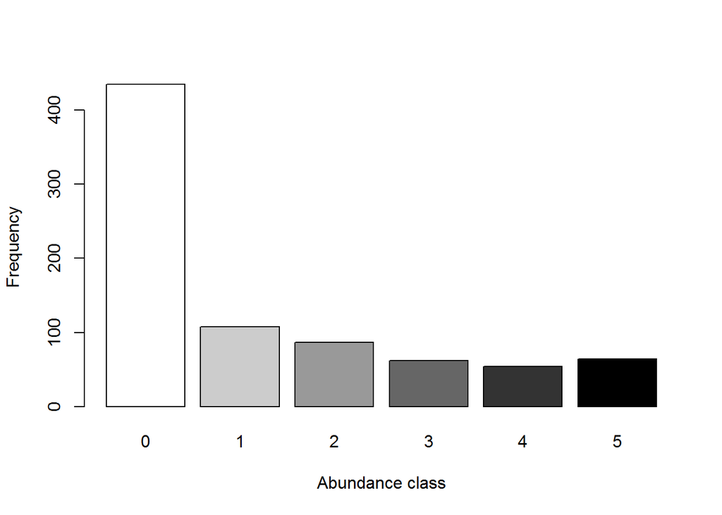

```r
ab <- table(unlist(spe))
barplot(ab,
        xlab = "Abundance class",
        ylab = "Frequency",
        col = gray(5 : 0/5)) # 5 : 0/5 >> c(1.0, 0.8, 0.6, 0.4, 0.2, 0.0)
```

```r
sum(spe == 0) # 统计元素是 0 的个数
```

```
## [1] 435
```

```r
sum(spe == 0) / (nrow(spe) * ncol(spe)) # 计算频率
```

```
## [1] 0.537037
```

> 1. 注意条形图中如何定义的 灰度： 5 : 0/5 运算顺序;
> 2. 该如何理解 0 值的高频率？？？

### 2.2.3 物种数据: 近距

进一步探索 Doubs 河流数据集其子数据集的其他属性： 创建采样点（位点）的地理分布图

```r
head(spa) # 查看使用的地理位置数据集（经纬度）
```

```
##        X      Y
## 1 85.678 20.000
## 2 84.955 20.100
## 3 92.301 23.796
## 4 91.280 26.431
## 5 92.005 29.163
## 6 95.954 36.315
```

```r
dim(spa) # 查看数据维度
```

```
## [1] 30  2
```

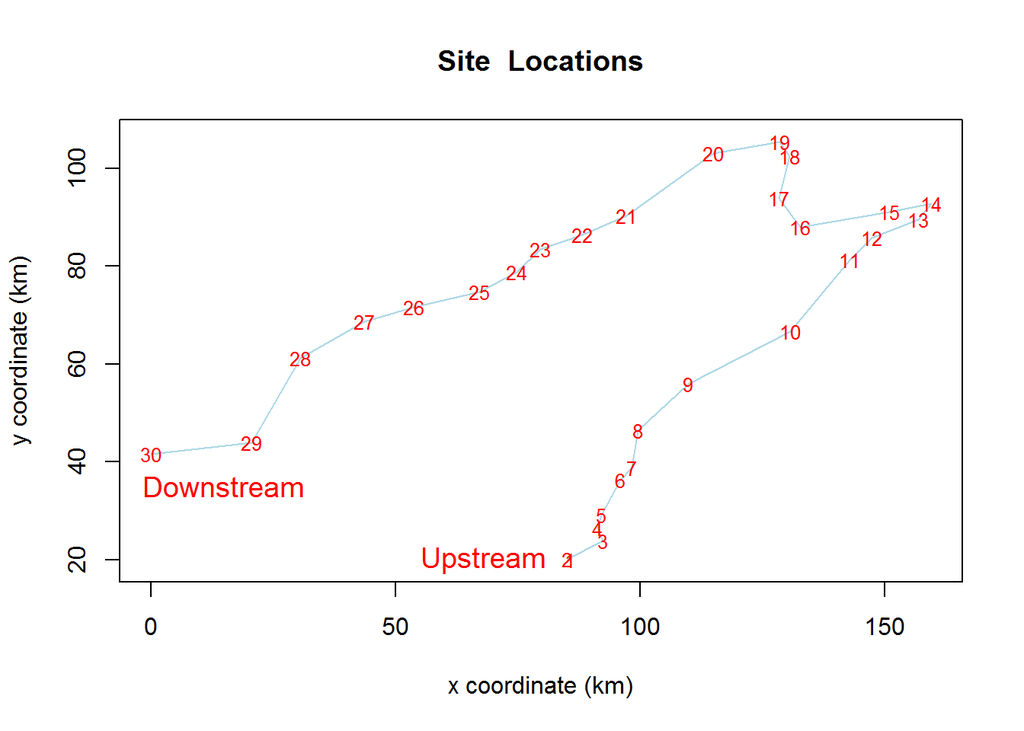

```r
plot(spa,
     asp  =  1, # 显示的纵横比
     type = "n", # 选择的绘图类型，n - 不绘制；l - 线；p - 点
     main =  "Site  Locations", # 主标题
     xlab = "x coordinate (km)", # 副标题
     ylab = "y coordinate (km)" # 副标题
     )
lines(spa, col = "light blue") # 添加线，并设置颜色
text(spa,  row.names(spa),
     cex  =  0.8,  col  =  "red") # 添加位点的标签（行名
text(68,  20,  "Upstream",
     cex  =  1.2,  col  =  "red") # 在固定位置添加文本注释
text(15,  35,  "Downstream",
     cex  =  1.2,  col  =  "red") # 在固定位置添加文本注释
```

当位点的地理信息数据涵盖较大范围时，可以将其投射到 GoogleMap 上 > 有些类似于 leaflet； 国内访问受限

```r
library(googleVis) # 导入分析包

head(latlong) # 查看数据
```

```
##   Site LatitudeN LongitudeE
## 1    1  46.70800   6.203811
## 2    2  46.70890   6.194362
## 3    3  46.74214   6.290432
## 4    4  46.76585   6.277074
## 5    5  46.79043   6.286561
## 6    6  46.85476   6.338203
```

```r
nom <- latlong$Site # 位点名称赋值于 nom 变量
latlong2  <-  paste(latlong$LatitudeN,
                    latlong$LongitudeE,
                    sep  =  ":") # 两列合并生成 新向量
df  <-  data.frame(latlong2, nom, stringsAsFactors  =  FALSE) # 创建数据框(30行,2列)
mymap1 <- gvisMap(df,
                  locationvar  =  "latlong2",
                  tipvar  =  "nom",
                  options = list(showTip = TRUE)
                  )
#plot(mymap1) # 国内访问受限
```

在河流显示的基础上进行 4 种不同鱼类的分布于丰度展示：

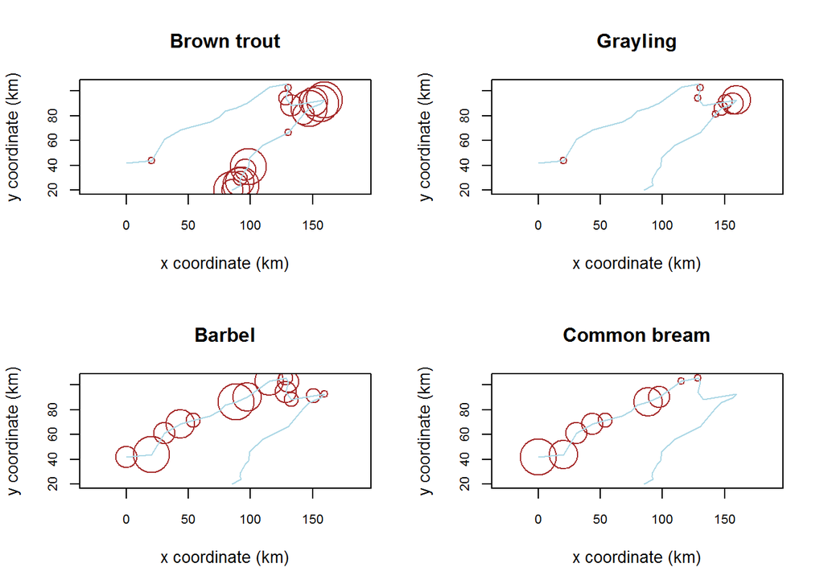

```r
par(mfrow = c(2,2)) # 设置绘图区域，2 行 2 列共 4 框

plot(spa,
     asp = 1,
     cex.axis = 0.8,
     col = "brown",
     cex = spe$Satr, # 表征物种丰度
     main = "Brown trout",
     xlab = "x coordinate (km)",
     ylab = "y coordinate (km)") # 描绘该物种的分布以及丰富度
lines(spa, col = "light blue")

plot(spa,
     asp = 1,
     cex.axis = 0.8,
     col = "brown",
     cex = spe$Thth, # 表征物种丰度
     main = "Grayling",
     xlab = "x coordinate (km)",
     ylab = "y coordinate (km)") # 描绘该物种的分布以及丰富度
lines(spa, col = "light blue")

plot(spa,
     asp = 1,
     cex.axis = 0.8,
     col = "brown",
     cex = spe$Baba, # 表征物种丰度
     main = "Barbel",
     xlab = "x coordinate (km)",
     ylab = "y coordinate (km)") # 描绘该物种的分布以及丰富度
lines(spa, col = "light blue")

plot(spa,
     asp = 1,
     cex.axis = 0.8,
     col = "brown",
     cex = spe$Abbr, # 表征物种丰度
     main = "Common bream",
     xlab = "x coordinate (km)",
     ylab = "y coordinate (km)") # 描绘该物种的分布以及丰富度
lines(spa, col = "light blue")
```

> 参数 cex 表征了 4 种不同鱼类的丰度

探索每个物种存在于多少个位点，即物种出现的频次和频率统计(绘制直方图 - histograms)：

```r
spe.pres <- apply(spe > 0, 2, sum) # 按照列方向计数 > 0 的个数（向量保存）
sort(spe.pres) # 升序排列
```

```
## Icme Cogo Thth Teso Abbr Blbj Pato Rham Scer Anan Chna Albi Cyca Gyce Legi
##    7    8    8    8    9   10   11   11   11   11   12   12   12   12   13
## Baba Alal Pefl Satr Titi Lele Eslu Ruru Phph Gogo Babl Sqce
##   14   14   15   17   17   18   18   18   20   20   24   25
```

```r
spe.relf <- 100 * spe.pres/nrow(spe) # 计算频率
round(sort(spe.relf), 1) # 保留一位小数
```

```
## Icme Cogo Thth Teso Abbr Blbj Pato Rham Scer Anan Chna Albi Cyca Gyce Legi
## 23.3 26.7 26.7 26.7 30.0 33.3 36.7 36.7 36.7 36.7 40.0 40.0 40.0 40.0 43.3
## Baba Alal Pefl Satr Titi Lele Eslu Ruru Phph Gogo Babl Sqce
## 46.7 46.7 50.0 56.7 56.7 60.0 60.0 60.0 66.7 66.7 80.0 83.3
```

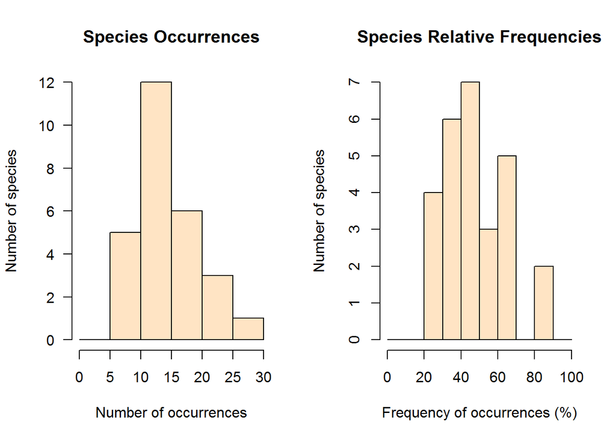

```r
par(mfrow = c(1,2)) # 设置绘图区域( 1 行, 2 列)
hist(spe.pres,
     right = F, # 区间 左闭右开
     las = 1,
     main = "Species Occurrences",
     xlab = "Number of occurrences",
     ylab = "Number of species",
     breaks = seq(0, 30, by = 5), # seq(0, 30, by = 5) >> c(0, 5, 10, 15, 20, 25, 30)
     col = "bisque")
hist(spe.relf,
     right = F, # 区间 左闭右开
     main = "Species Relative Frequencies",
     xlab = "Frequency of occurrences (%)",
     ylab = "Number of species",
     breaks = seq(0, 100, by = 10), # 坐标轴的间隔分段
     col = "bisque")
```

> apply( , , ) 按照 行/列 方向对数据进行 某种函数运算/统计

探索每个位点有多少个物种数量：

```r
sit.pres <- apply(spe > 0, 1, sum) # 按照行方向计数 > 0 的个数（向量保存）
sort(sit.pres) # 升序排列
```

```
##  8  1  2 23  3  7  9 10 11 12 13  4 24 25  6 14  5 15 16 26 30 17 20 22 27
##  0  1  3  3  4  5  5  6  6  6  6  8  8  8 10 10 11 11 17 21 21 22 22 22 22
## 28 18 19 21 29
## 22 23 23 23 26
```

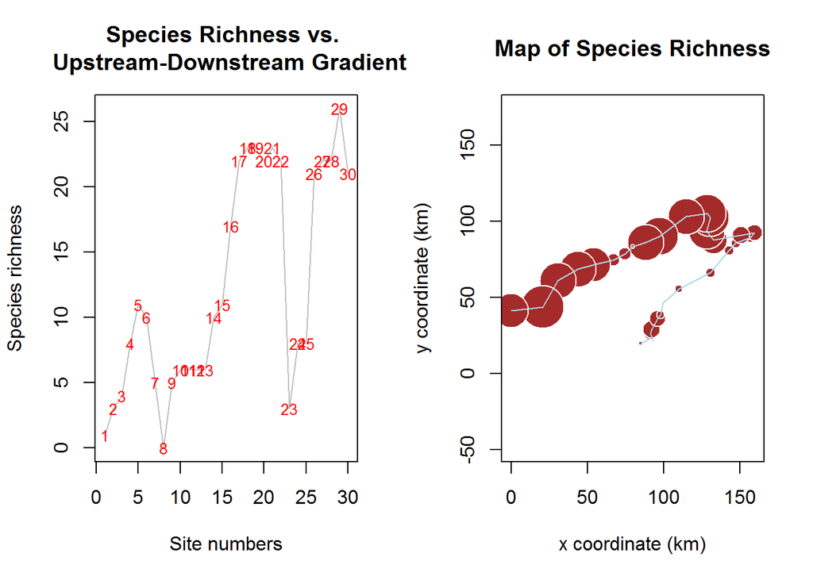

```r
par(mfrow = c(1, 2))  # 设置绘图区域( 1 行, 2 列)
plot(sit.pres,
     type = "l", # 阶梯绘图 - stair steps； 可尝试 type = "l"
     col = "gray",
     main = "Species Richness vs. \n Upstream-Downstream Gradient",
     xlab = "Site numbers",
     ylab = "Species richness"
     )
text(sit.pres, row.names(spe), cex = .8, col = "red")
plot(spa,
     asp = 1,
     pch = 21,
     col = "white",
     bg = "brown",
     cex = 5 * sit.pres / max(sit.pres), # cex 被赋值了 新向量
     main = "Map of Species Richness",
     xlab = "x coordinate (km)",
     ylab = "y coordinate (km)"
     )
lines(spa, col = "light blue")
```

### 2.2.4 生态数据类型转换

有时，需要基于以下几种情况对生态类群数据进行格式转换：

物种丰度数据在维度上为同质化、定量、半定量的变量类型，数据的数值仅限于正值或者空值（0）。 通过简单的数值变换sqrt()、 ^0.25、log1p() (log(y + 1)保持缺省值为零)等以降低高值的观察值的影响。 在某些个别的案例中，为赋予相同的权重，可以将原数据转换为“有-无”二值类型。

vegan() 分析包的 decostand() 函数提供了多种生态类型数据标准化的选项，行列间数据进行相互比较转换（有别于简单的数值变换）。 可以相对于位点作标准化（每个位点的相对丰度），也可以相对于物种作标准化（与物种最大丰度有关的丰度或者与总丰度相关的丰度），或者同时位点和物种总量的作标准化（卡方转换）–以上的各种不同的变换方式主要取决于分析的目的。

decostand() 中有对数转换的功能，这种转换是对 y > 0 的数值进行的 log_b(y) + 1 的对数转换，其中 b 是对数转换的基数。在这种分析过程中 0 值未被触及，同时对数转换中的基数 b 由logbase 所提供。 上述这种对数转换于 2006 年 Anderson 等提出的 log(y + 1) 的对数转换不一样。 增加对数基数会增加大值缩小的严重性。

通过箱式图（boxplots）展示部分数据的标准化处理：

```r
library(vegan) # 导入分析包
#?decostand # 查询函数功能的基本介绍
spe[1:5, 2:4] # 查看数据子集
```

```
##   Satr Phph Babl
## 1    3    0    0
## 2    5    4    3
## 3    5    5    5
## 4    4    5    5
## 5    2    3    2
```

```r
spe.pa <- decostand(spe, method = "pa") # “有-无”二进制数据转换
spe.pa[1:5, 2:4] # 查看数据子集
```

```
##   Satr Phph Babl
## 1    1    0    0
## 2    1    1    1
## 3    1    1    1
## 4    1    1    1
## 5    1    1    1
```

```r
spe.scal <- decostand(spe, "max") # 对数据框按列进行标准化处理
spe.scal[1:5, 2:4] # 前后呼应查看数据转换后的异同
```

```
##   Satr Phph Babl
## 1  0.6  0.0  0.0
## 2  1.0  0.8  0.6
## 3  1.0  1.0  1.0
## 4  0.8  1.0  1.0
## 5  0.4  0.6  0.4
```

```r
apply(spe.scal, 2, max) # 按列方向展示最大值
```

```
## Cogo Satr Phph Babl Thth Teso Chna Pato Lele Sqce Baba Albi Gogo Eslu Pefl
##    1    1    1    1    1    1    1    1    1    1    1    1    1    1    1
## Rham Legi Scer Cyca Titi Abbr Icme Gyce Ruru Blbj Alal Anan
##    1    1    1    1    1    1    1    1    1    1    1    1
```

按照行/列方向统计数据结果;

```r
spe.relsp <- decostand(spe, "total", MARGIN = 2) # 按列方向进行标准化处理；物种相对丰度
spe.relsp[1:5, 2:4]
```

```
##         Satr       Phph       Babl
## 1 0.05263158 0.00000000 0.00000000
## 2 0.08771930 0.05882353 0.04109589
## 3 0.08771930 0.07352941 0.06849315
## 4 0.07017544 0.07352941 0.06849315
## 5 0.03508772 0.04411765 0.02739726
```

```r
colSums(spe.relsp) # 按列求和 | apply(spe.relsp, 2, sum)
```

```
## Cogo Satr Phph Babl Thth Teso Chna Pato Lele Sqce Baba Albi Gogo Eslu Pefl
##    1    1    1    1    1    1    1    1    1    1    1    1    1    1    1
## Rham Legi Scer Cyca Titi Abbr Icme Gyce Ruru Blbj Alal Anan
##    1    1    1    1    1    1    1    1    1    1    1    1
```

```r
spe.rel <- decostand(spe, "total", MARGIN = 1) # 按行方向标准化；位点的相对丰度
spe.rel[1:5, 2:4]
```

```
##         Satr       Phph       Babl
## 1 1.00000000 0.00000000 0.00000000
## 2 0.41666667 0.33333333 0.25000000
## 3 0.31250000 0.31250000 0.31250000
## 4 0.19047619 0.23809524 0.23809524
## 5 0.05882353 0.08823529 0.05882353
```

```r
rowSums(spe.rel) # 按行求和 | apply(spe.rel, 1, sum)
```

```
##  1  2  3  4  5  6  7  8  9 10 11 12 13 14 15 16 17 18 19 20 21 22 23 24 25
##  1  1  1  1  1  1  1  0  1  1  1  1  1  1  1  1  1  1  1  1  1  1  1  1  1
## 26 27 28 29 30
##  1  1  1  1  1
```

```r
# Give a length (norm) of 1 to each row vector
# This is called the chord transformation
spe.norm <- decostand(spe, "normalize") # 按行方向标准化 [0, 1]；MARGIN = 1
spe.norm[1:5, 2:4]
```

```
##        Satr      Phph      Babl
## 1 1.0000000 0.0000000 0.0000000
## 2 0.7071068 0.5656854 0.4242641
## 3 0.5735393 0.5735393 0.5735393
## 4 0.4558423 0.5698029 0.5698029
## 5 0.1825742 0.2738613 0.1825742
```

```r
vec.norm <- function(x) sqrt(sum(x ^ 2)) # 平方再开方 >> 负值转换成正值
apply(spe.norm, 1, vec.norm) # 按行方向
```

```
##  1  2  3  4  5  6  7  8  9 10 11 12 13 14 15 16 17 18 19 20 21 22 23 24 25
##  1  1  1  1  1  1  1  0  1  1  1  1  1  1  1  1  1  1  1  1  1  1  1  1  1
## 26 27 28 29 30
##  1  1  1  1  1
```

上述的转换被称作是“chord 变换” – 弦变换，Euclidean距离函数应用弦变换产生弦距离矩阵（章3）。 在PCA和RDA以及k-均值分析中都有弦变换相应的应用。 弦变换同样也可应用于对数变换的数据处理过程中。

```r
# 计算每个位点的相对丰度的平方根
spe.hel <- decostand(spe, "hellinger") #  平方根 of method = "total"
spe.hel[1:5, 2:4]
```

```
##        Satr      Phph      Babl
## 1 1.0000000 0.0000000 0.0000000
## 2 0.6454972 0.5773503 0.5000000
## 3 0.5590170 0.5590170 0.5590170
## 4 0.4364358 0.4879500 0.4879500
## 5 0.2425356 0.2970443 0.2425356
```

```r
vec.norm <- function(x) sqrt(sum(x ^ 2)) # 平方再开方 >> 负值转换成正值
apply(spe.hel, 1, vec.norm)
```

```
##  1  2  3  4  5  6  7  8  9 10 11 12 13 14 15 16 17 18 19 20 21 22 23 24 25
##  1  1  1  1  1  1  1  0  1  1  1  1  1  1  1  1  1  1  1  1  1  1  1  1  1
## 26 27 28 29 30
##  1  1  1  1  1
```

上述的转换被称作是“Hellinger 变换”

```r
# 通过行列进行双重标准化
spe[1:5, 2:4]
```

```
##   Satr Phph Babl
## 1    3    0    0
## 2    5    4    3
## 3    5    5    5
## 4    4    5    5
## 5    2    3    2
```

```r
spe.chi <- decostand(spe, "chi.square")
spe.chi[1:5, 2:4] # 观察数据集前后的变化
```

```
##        Satr      Phph      Babl
## 1 4.1969078 0.0000000 0.0000000
## 2 1.7487116 1.2808290 0.9271402
## 3 1.3115337 1.2007772 1.1589253
## 4 0.7994110 0.9148778 0.8829907
## 5 0.2468769 0.3390430 0.2181506
```

```r
spe.chi[7:9, ]
```

```
##   Cogo     Satr      Phph      Babl Thth Teso Chna Pato     Lele      Sqce
## 7    0 1.311534 0.9606217 1.1589253    0    0    0    0 0.302004 0.2646384
## 8    0 0.000000 0.0000000 0.0000000    0    0    0    0 0.000000 0.0000000
## 9    0 0.000000 0.2744634 0.7946916    0    0    0    0 0.000000 1.5122194
##   Baba Albi Gogo Eslu Pefl Rham Legi Scer Cyca      Titi Abbr Icme Gyce
## 7    0    0    0    0    0    0    0    0    0 0.0000000    0    0    0
## 8    0    0    0    0    0    0    0    0    0 0.0000000    0    0    0
## 9    0    0    0    0    0    0    0    0    0 0.3373903    0    0    0
##       Ruru Blbj Alal Anan
## 7 0.000000    0    0    0
## 8 0.000000    0    0    0
## 9 1.140587    0    0    0
```

```r
# Wisconsin standardization -- 双重标准化
# 在按行总数标准化之前，每个值首先由列最大值标准化
# 物种 - 列方向；位点 - 行方向
spe.wis <- wisconsin(spe)
spe.wis[1:5,2:4]
```

```
##         Satr       Phph       Babl
## 1 1.00000000 0.00000000 0.00000000
## 2 0.41666667 0.33333333 0.25000000
## 3 0.31250000 0.31250000 0.31250000
## 4 0.19047619 0.23809524 0.23809524
## 5 0.05882353 0.08823529 0.05882353
```

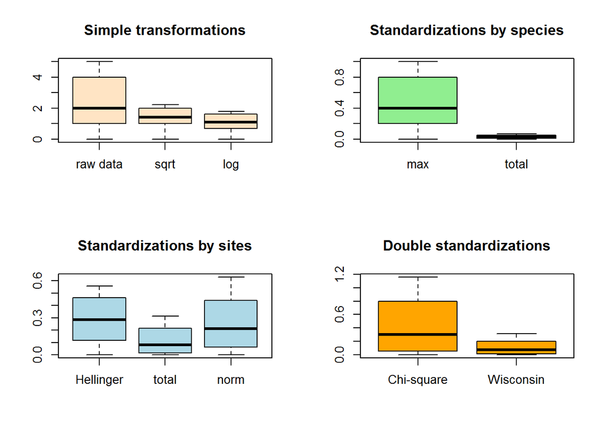

```r
par(mfrow = c(2,2)) # 设置绘图区域( 2 行, 2 列)
boxplot(spe$Babl,
        sqrt(spe$Babl),
        log1p(spe$Babl), # 设置 3 个离散变量
        main = "Simple transformations",
        names = c("raw data", "sqrt", "log"), # 设置 3 个离散变量的坐标轴标签
        col = "bisque"
        )
boxplot(spe.scal$Babl,
        spe.relsp$Babl,
        main = "Standardizations by species",
        names = c("max", "total"),
        col = "lightgreen"
        )
boxplot(spe.hel$Babl,
        spe.rel$Babl,
        spe.norm$Babl,
        main = "Standardizations by sites",
        names = c("Hellinger", "total", "norm"),
        col = "lightblue"
        )
boxplot(spe.chi$Babl,
        spe.wis$Babl,
        main = "Double standardizations",
        names = c("Chi-square", "Wisconsin"),
        col = "orange"
        )
```

> 自定义函数的标准格式：newfun <- function(x) fun(x)

比较分析数值变换和标准化之后的影响（可视化）：

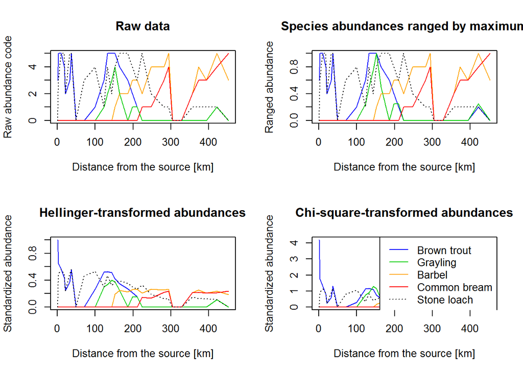

```r
par(mfrow = c(2, 2)) # 设置绘图区域( 2 行, 2 列)

plot(env$dfs,
     spe$Satr,
     type = "l",
     col = 4,
     main = "Raw data",
     xlab = "Distance from the source [km]",
     ylab = "Raw abundance code"
     )
lines(env$dfs, spe$Thth, col = 3)
lines(env$dfs, spe$Baba, col = "orange")
lines(env$dfs, spe$Abbr, col = 2)
lines(env$dfs, spe$Babl, col = 1, lty = "dotted")

plot(env$dfs,
     spe.scal$Satr,
     type = "l",
     col = 4,
     main = "Species abundances ranged by maximum",
     xlab = "Distance from the source [km]",
     ylab = "Ranged abundance"
     )
lines(env$dfs, spe.scal$Thth, col = 3)
lines(env$dfs, spe.scal$Baba, col = "orange")
lines(env$dfs, spe.scal$Abbr, col = 2)
lines(env$dfs, spe.scal$Babl, col = 1, lty = "dotted")

plot(env$dfs,
     spe.hel$Satr,
     type = "l",
     col = 4,
     main = "Hellinger-transformed abundances",
     xlab = "Distance from the source [km]",
     ylab = "Standardized abundance"
     )
lines(env$dfs, spe.hel$Thth, col = 3)
lines(env$dfs, spe.hel$Baba, col = "orange")
lines(env$dfs, spe.hel$Abbr, col = 2)
lines(env$dfs, spe.hel$Babl, col = 1, lty = "dotted")

plot(env$dfs,
     spe.chi$Satr,
     type = "l",
     col = 4,
     main = "Chi-square-transformed abundances",
     xlab = "Distance from the source [km]",
     ylab = "Standardized abundance"
     )
lines(env$dfs, spe.chi$Thth, col = 3)
lines(env$dfs, spe.chi$Baba, col = "orange")
lines(env$dfs, spe.chi$Abbr, col = 2)
lines(env$dfs, spe.chi$Babl, col = 1, lty = "dotted")
legend("topright",
       c("Brown trout", "Grayling", "Barbel",
         "Common bream", "Stone loach"),
       col = c(4, 3, "orange", 2, 1),
       lty = c(rep(1, 4), 3)
       )
```

*比较上述图形，并尝试解释相互之间的差别*

对于离散型数据，某些情况下可以使用 labdsv 分析包中的 vegtrans() 函数进行尺度转换。 按照特定的比例尺进行数据变换，一个向量保存当前的数据尺度，另一个向量保存转换后的比例尺度。

```r
# 使用自定义的比例尺度转换鱼类丰度数据
current <- c(0, 1, 2, 3, 4, 5)
converted <- c(0, 1 ,5, 10, 20, 50) # 自定义的比例尺度
spe.conv <- vegtrans(spe, current, converted)
head(spe.conv)
```

```
##   Cogo Satr Phph Babl Thth Teso Chna Pato Lele Sqce Baba Albi Gogo Eslu
## 1    0   10    0    0    0    0    0    0    0    0    0    0    0    0
## 2    0   50   20   10    0    0    0    0    0    0    0    0    0    0
## 3    0   50   50   50    0    0    0    0    0    0    0    0    0    1
## 4    0   20   50   50    0    0    0    0    0    1    0    0    1    5
## 5    0    5   10    5    0    0    0    0   50    5    0    0    5   20
## 6    0   10   20   50    0    0    0    0    1    5    0    0    1    1
##   Pefl Rham Legi Scer Cyca Titi Abbr Icme Gyce Ruru Blbj Alal Anan
## 1    0    0    0    0    0    0    0    0    0    0    0    0    0
## 2    0    0    0    0    0    0    0    0    0    0    0    0    0
## 3    0    0    0    0    0    0    0    0    0    0    0    0    0
## 4    5    0    0    0    0    1    0    0    0    0    0    0    0
## 5   20    0    0    5    0   10    0    0    0   50    0    0    0
## 6    1    0    0    0    0    5    0    0    0    1    0    0    0
```

### 2.2.5 环境数据

接下来了解 Doubs 河流数据集的环境数据信息，绘图环境变量图：

```r
head(env) # 查看数据前 6 行
```

```
##    dfs ele  slo  dis  pH har  pho  nit  amm  oxy bod
## 1  0.3 934 48.0 0.84 7.9  45 0.01 0.20 0.00 12.2 2.7
## 2  2.2 932  3.0 1.00 8.0  40 0.02 0.20 0.10 10.3 1.9
## 3 10.2 914  3.7 1.80 8.3  52 0.05 0.22 0.05 10.5 3.5
## 4 18.5 854  3.2 2.53 8.0  72 0.10 0.21 0.00 11.0 1.3
## 5 21.5 849  2.3 2.64 8.1  84 0.38 0.52 0.20  8.0 6.2
## 6 32.4 846  3.2 2.86 7.9  60 0.20 0.15 0.00 10.2 5.3
```

```r
summary(env) # 按列统计数据基本信息
```

```
##       dfs              ele             slo              dis
##  Min.   :  0.30   Min.   :172.0   Min.   : 0.200   Min.   : 0.84
##  1st Qu.: 54.45   1st Qu.:248.0   1st Qu.: 0.525   1st Qu.: 4.20
##  Median :175.20   Median :395.0   Median : 1.200   Median :22.10
##  Mean   :188.23   Mean   :481.6   Mean   : 3.497   Mean   :22.20
##  3rd Qu.:301.73   3rd Qu.:782.0   3rd Qu.: 2.875   3rd Qu.:28.57
##  Max.   :453.00   Max.   :934.0   Max.   :48.000   Max.   :69.00
##        pH             har              pho              nit
##  Min.   :7.700   Min.   : 40.00   Min.   :0.0100   Min.   :0.150
##  1st Qu.:7.925   1st Qu.: 84.25   1st Qu.:0.1250   1st Qu.:0.505
##  Median :8.000   Median : 89.00   Median :0.2850   Median :1.600
##  Mean   :8.050   Mean   : 86.10   Mean   :0.5577   Mean   :1.654
##  3rd Qu.:8.100   3rd Qu.: 96.75   3rd Qu.:0.5600   3rd Qu.:2.425
##  Max.   :8.600   Max.   :110.00   Max.   :4.2200   Max.   :6.200
##       amm              oxy              bod
##  Min.   :0.0000   Min.   : 4.100   Min.   : 1.300
##  1st Qu.:0.0000   1st Qu.: 8.025   1st Qu.: 2.725
##  Median :0.1000   Median :10.200   Median : 4.150
##  Mean   :0.2093   Mean   : 9.390   Mean   : 5.117
##  3rd Qu.:0.2000   3rd Qu.:10.900   3rd Qu.: 5.275
##  Max.   :1.8000   Max.   :12.400   Max.   :16.700
```

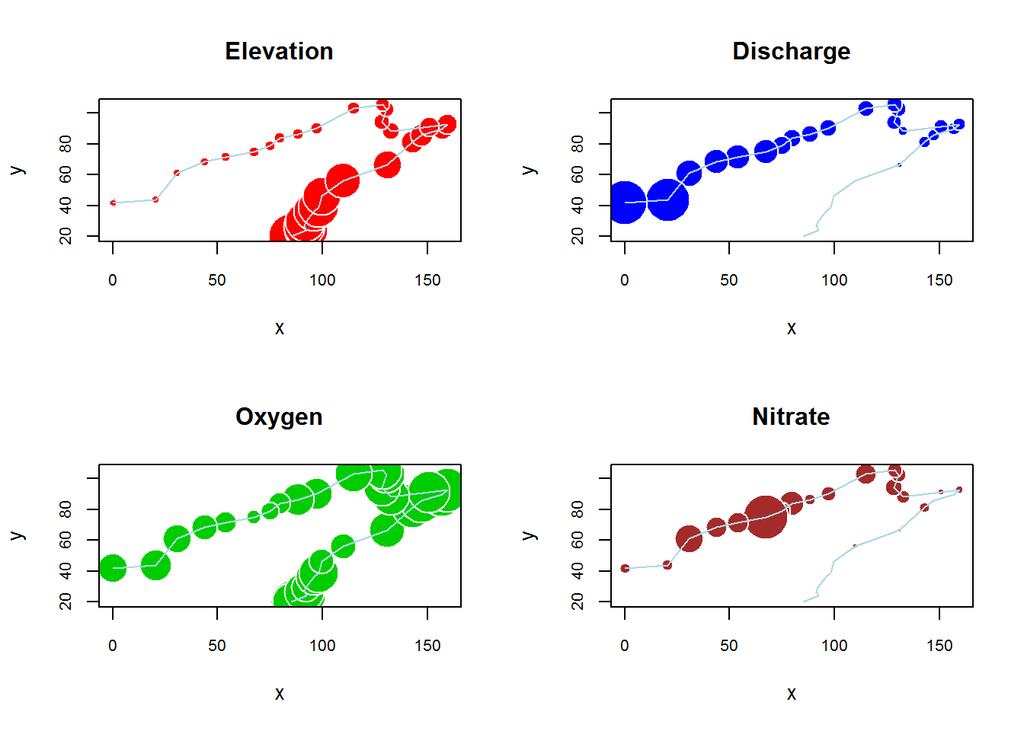

```r
par(mfrow = c(2, 2)) # 设置绘图区域( 2 行, 2 列)

plot(spa,
     cex.axis = 0.8, # 坐标轴注释文字的放大倍数
     pch = 21, # 形状 -- 圆圈
     col = "white", # 轮廓 -- 白色
     bg = "red", # 填充色 -- 红色
     cex = 5 * env$ele / max(env$ele), # 表征圆圈大小 | 生成的向量 赋值给 cex
     main = "Elevation",
     xlab = "x",
     ylab = "y")
lines(spa, col = "light blue")

plot(spa,
     cex.axis = 0.8, # 坐标轴注释文字的放大倍数
     pch = 21,
     col = "white",
     bg = "blue",
     cex = 5 * env$dis / max(env$dis), # 表征圆圈大小 | 生成的向量 赋值给 cex
     main = "Discharge",
     xlab = "x",
     ylab = "y"
     )
lines(spa, col = "light blue")

plot(spa,
     cex.axis = 0.8, # 坐标轴注释文字的放大倍数
     pch = 21,
     col = "white",
     bg = "green3",
     cex = 5 * env$oxy / max(env$oxy), # 表征圆圈大小 | 生成的向量 赋值给 cex
     main = "Oxygen",
     xlab = "x",
     ylab = "y"
     )
lines(spa, col = "light blue")

plot(spa,
     cex.axis = 0.8, # 坐标轴注释文字的放大倍数
     pch = 21,
     col = "white",
     bg = "brown",
     cex = 5 * env$nit / max(env$nit), # 表征圆圈大小 | 生成的向量 赋值给 cex
     main = "Nitrate",
     xlab = "x",
     ylab = "y"
)
lines(spa, col = "light blue")
```

使用线型图表示河流沿岸某些变量的变化与波动：

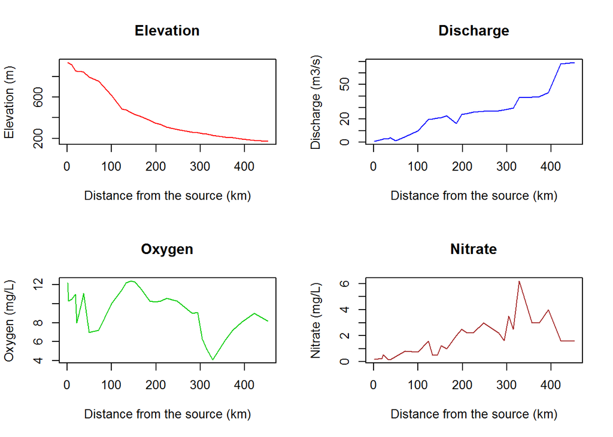

```r
par(mfrow = c(2, 2)) # 设置绘图区域( 2 行, 2 列)
plot(env$dfs,
     env$ele,
     type = "l",
     xlab = "Distance from the source (km)",
     ylab = "Elevation (m)",
     col = "red",
     main = "Elevation")
plot(env$dfs,
     env$dis,
     type = "l",
     xlab = "Distance from the source (km)",
     ylab = "Discharge (m3/s)",
     col = "blue",
     main = "Discharge")
plot(env$dfs,
     env$oxy,
     type = "l",
     xlab = "Distance from the source (km)",
     ylab = "Oxygen (mg/L)",
     col = "green3",
     main = "Oxygen")
plot(env$dfs,
     env$nit,
     type = "l",
     xlab = "Distance from the source (km)",
     ylab = "Nitrate (mg/L)",
     col = "brown",
     main = "Nitrate")
```

使用散点矩阵图（Scatter plots）研究环境变量之间的二元关系：

```r
head(env) # 查看数据前 6 行
```

```
##    dfs ele  slo  dis  pH har  pho  nit  amm  oxy bod
## 1  0.3 934 48.0 0.84 7.9  45 0.01 0.20 0.00 12.2 2.7
## 2  2.2 932  3.0 1.00 8.0  40 0.02 0.20 0.10 10.3 1.9
## 3 10.2 914  3.7 1.80 8.3  52 0.05 0.22 0.05 10.5 3.5
## 4 18.5 854  3.2 2.53 8.0  72 0.10 0.21 0.00 11.0 1.3
## 5 21.5 849  2.3 2.64 8.1  84 0.38 0.52 0.20  8.0 6.2
## 6 32.4 846  3.2 2.86 7.9  60 0.20 0.15 0.00 10.2 5.3
```

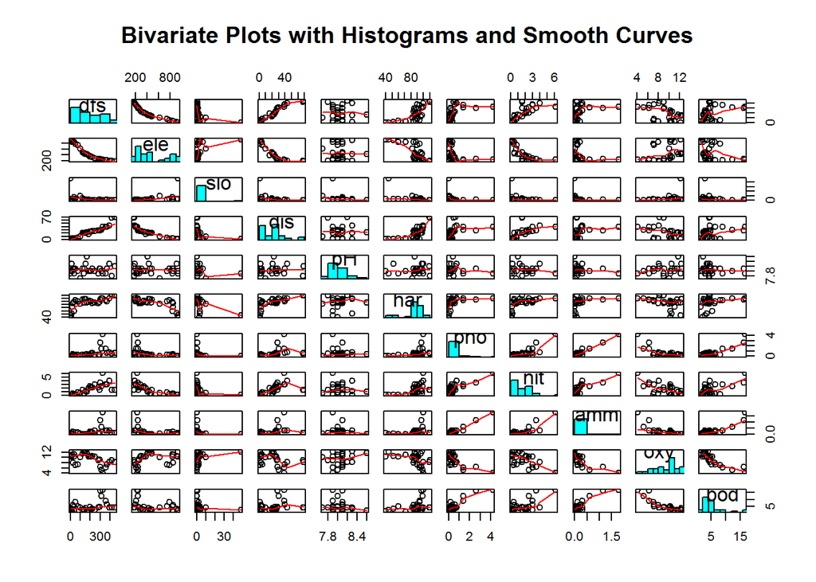

```r
# 二元图（Bivariate plots）= 对角线直方图 + 拟合曲线
pairs(env,
      panel = panel.smooth, # 非对角线区的面板绘制拟合曲线
      diag.panel = panel.hist, # 对角线区的面板绘制直方图
      main = "Bivariate Plots with Histograms and Smooth Curves"
      )
```

> 1. 从对角线的直方图中，可以判断哪些变量是正态分布的；
> 2. 回归分析(regression analysis)和规范排序分析(canonical ordination)中的解释变量不需要满足正态分布；
> 3. 散点图所表示的线性或者单调关系

环境变量数据是异质性的，使用不同的单位和尺度进行表示，很多统计分析需要将其标准化为零均值和单位方差。这些中心化和缩放的变量称之为 “z-scores”。示例数据展示：

```r
range(env$slo) # 查看变化范围
```

```
## [1]  0.2 48.0
```

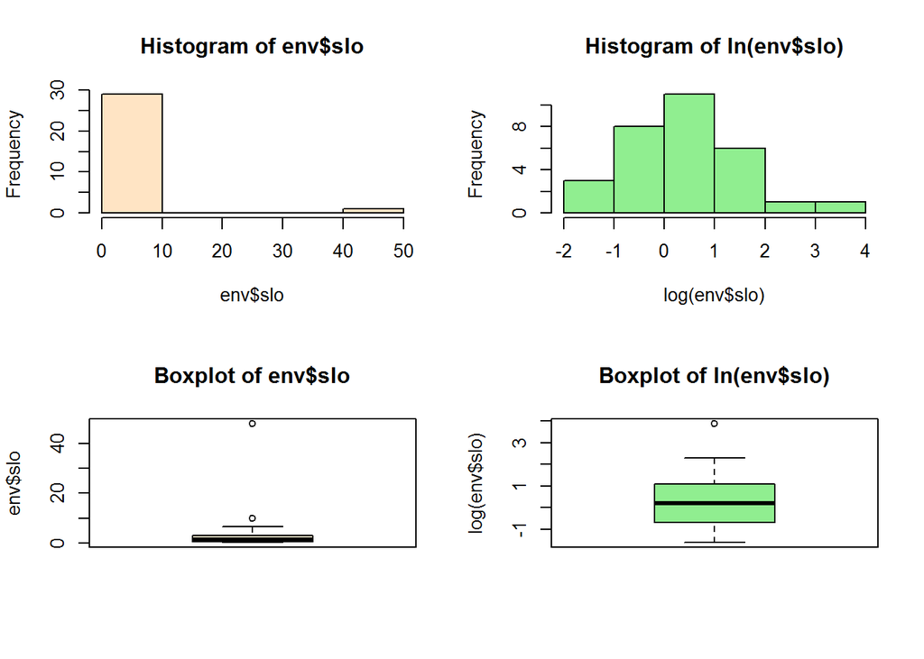

```r
par(mfrow = c(2, 2)) # 设置绘图区域( 2 行, 2 列)
hist(env$slo,
     col = "bisque",
     right = FALSE # 区间 左闭右开
     )
hist(log(env$slo),
     col = "light green",
     right = FALSE, # 区间 左闭右开
     main = "Histogram of ln(env$slo)"
     )
boxplot(env$slo,
        col = "bisque",
        main = "Boxplot of env$slo",
        ylab = "env$slo")
boxplot(log(env$slo),
        col = "light green",
        main = "Boxplot of ln(env$slo)",
        ylab = "log(env$slo)"
        )
```

```r
env.z <- decostand(env, "standardize") # 按行方向标准化处理
apply(env.z, 2, mean) # 按列方向求平均值
```

```
##           dfs           ele           slo           dis            pH
##  7.847455e-17  2.453911e-17 -1.659010e-17  1.233099e-17 -4.096709e-15
##           har           pho           nit           amm           oxy
##  3.348595e-16  1.327063e-17 -8.925898e-17 -4.289646e-17 -2.886092e-16
##           bod
##  7.656545e-17
```

```r
apply(env.z, 2, sd) # 按列方向求标准差
```

```
## dfs ele slo dis  pH har pho nit amm oxy bod
##   1   1   1   1   1   1   1   1   1   1   1
```

```r
head(env.z)
```

```
##         dfs      ele         slo       dis         pH        har
## 1 -1.349676 1.667335  5.14106053 -1.180045 -0.8635475 -2.4369581
## 2 -1.336030 1.659965 -0.05737533 -1.171206 -0.2878492 -2.7334250
## 3 -1.278577 1.593630  0.02348923 -1.127011  1.4392458 -2.0219044
## 4 -1.218969 1.372514 -0.03427117 -1.086684 -0.2878492 -0.8360367
## 5 -1.197424 1.354088 -0.13823989 -1.080607  0.2878492 -0.1245161
## 6 -1.119144 1.343032 -0.03427117 -1.068454 -0.8635475 -1.5475573
##          pho        nit         amm        oxy         bod
## 1 -0.6248726 -1.0287408 -0.55225131  1.2685942 -0.62541885
## 2 -0.6134629 -1.0287408 -0.28843699  0.4108259 -0.83245406
## 3 -0.5792337 -1.0145903 -0.42034415  0.5011173 -0.41838364
## 4 -0.5221851 -1.0216655 -0.55225131  0.7268458 -0.98773046
## 5 -0.2027128 -0.8023329 -0.02462267 -0.6275252  0.28036017
## 6 -0.4080878 -1.0641170 -0.55225131  0.3656802  0.04744557
```

```r
head(as.data.frame(scale(env)))  # scale() 矩阵对象的缩放或局中
```

```
##         dfs      ele         slo       dis         pH        har
## 1 -1.349676 1.667335  5.14106053 -1.180045 -0.8635475 -2.4369581
## 2 -1.336030 1.659965 -0.05737533 -1.171206 -0.2878492 -2.7334250
## 3 -1.278577 1.593630  0.02348923 -1.127011  1.4392458 -2.0219044
## 4 -1.218969 1.372514 -0.03427117 -1.086684 -0.2878492 -0.8360367
## 5 -1.197424 1.354088 -0.13823989 -1.080607  0.2878492 -0.1245161
## 6 -1.119144 1.343032 -0.03427117 -1.068454 -0.8635475 -1.5475573
##          pho        nit         amm        oxy         bod
## 1 -0.6248726 -1.0287408 -0.55225131  1.2685942 -0.62541885
## 2 -0.6134629 -1.0287408 -0.28843699  0.4108259 -0.83245406
## 3 -0.5792337 -1.0145903 -0.42034415  0.5011173 -0.41838364
## 4 -0.5221851 -1.0216655 -0.55225131  0.7268458 -0.98773046
## 5 -0.2027128 -0.8023329 -0.02462267 -0.6275252  0.28036017
## 6 -0.4080878 -1.0641170 -0.55225131  0.3656802  0.04744557
```

## 2.3 结论

**探索性数据分析（EDA）在生态数据的初步分析中占有重要地位……**